# GLMMs

vmbolea

2025-12-19

# Data preparation

The data is coming from file “data/data_identity.xlsx”.

```r
library(dplyr)
library(ggplot2)
library(ggpubr)


#read data
data <- readxl::read_xlsx(path = "data/data_identity.xlsx",
                          sheet = "DESPLAZAMIENTO",
                          range =  "C1:V120")

print(data, n = 120)
```

```
## # A tibble: 119 × 20
##     created_at       uploaded_at `77_Hora_de_inicio` `78_Leader` `79_Seguidor_1`
##     <chr>            <chr>       <dttm>              <chr>       <chr>
##   1 2024-10-10T17:2… 2024-10-11… 1899-12-31 12:16:00 BUENO       BUENA
##   2 2024-10-10T15:2… 2024-10-11… 1899-12-31 10:23:00 TERE        DOS
##   3 2024-10-09T21:3… 2024-10-11… 1899-12-31 16:00:00 OSO         QUERIDA
##   4 2024-10-09T13:0… 2024-10-11… 1899-12-31 08:04:00 OSO         QUERIDA
##   5 2024-10-08T20:3… 2024-10-09… 1899-12-31 15:37:00 BUENO       OSO
##   6 2024-10-08T14:3… 2024-10-09… 1899-12-31 09:33:00 BUENO       BUENA
##   7 2024-10-07T19:2… 2024-10-09… 1899-12-31 14:09:00 OSO         QUERIDA
##   8 2024-10-07T17:3… 2024-10-09… 1899-12-31 12:34:00 CYNTHIA     QUERIDA
##   9 2024-10-07T14:5… 2024-10-09… 1899-12-31 09:54:00 BUENA       TERE
##  10 2024-09-26T18:3… 2024-10-09… 1899-12-31 13:31:00 BUENA       BUENO
##  11 2024-09-26T15:3… 2024-10-09… 1899-12-31 10:34:00 ABU         OSO
##  12 2024-09-25T18:3… 2024-10-09… 1899-12-31 13:34:00 BUENA       BUENO
```

[output cut: 113 more lines]

```r
source("data_preparation_period.R")

df <- read.csv("data/my_data_period.csv")

print(data_, n = 90)
```

```
## # A tibble: 88 × 11
##    ID       sex   repro_status context month n_leader n_follower n_front n_back
##    <chr>    <chr> <chr>        <chr>   <dbl>    <dbl>      <int>   <int>  <int>
##  1 ABU      F     AFC          Defense     1        0          5       4      1
##  2 ABU      F     AFC          Feeding     1        0          6       3      3
##  3 ABU      F     AFC          Defense     2        0         10       7      3
##  4 ABU      F     AFC          Feeding     2        1         15       4     11
##  5 ALHAMBRA F     AFL          Defense     0        1         19      14      5
##  6 ALHAMBRA F     AFL          Feeding     0       12         33      27      6
##  7 ALHAMBRA F     AFL          Defense     1        2          3       2      1
##  8 ALHAMBRA F     AFL          Feeding     1        1         12       9      3
##  9 BUBBLE   F     AFC          Defense     0        1         19       8     11
## 10 BUBBLE   F     AFC          Feeding     0        1         44      17     27
## 11 BUBBLE   F     AFC          Defense     1        0          5       3      2
## 12 BUBBLE   F     AFC          Feeding     1        0         13       1     12
```

[output cut: 77 more lines]

```r
df <- data_
```

# Linear mixed models(GLMM)

To investigate the factors influencing leadership probability, we fitted Generalized Linear Mixed Models (GLMMs) with a binomial error distribution and a logit link function, utilizing the lme4 package.

We constructed the response variable as a two-column matrix binding the number of times an individual acted as a leader versus the number of times they acted as a follower. We ran separate models for each of the two leadership contexts defined previously:

- 1. movements toward feeding trees and defense-related movements. To test our predictions regarding sex differences, we included sex as the fixed effect in the models for both contexts.
- 2. to evaluate the influence of female reproductive state, we analyzed a subset of the data containing only female subjects, with reproductive status (cycling, lactating, or with dependents) serving as the fixed predictor.

In all models, we included subject identity as a random intercept to control for repeated measures and potential pseudo-replication arising from sampling the same individuals multiple times. We determined the statistical significance of the fixed effects by performing Likelihood Ratio Tests (LRT), comparing the full models against null models that included only the random intercept, setting the significance threshold at p < .05.

## Formula for the first model

The model function for predictions where the number of times each individual moved toward as a given context (Feeding or Defense) as leader and as follower per month was added as a two‐vector response variable and the fixed predictor is given by the argument predictor (sex or reproductive status).

```r
run_model_leader_prop <- function(data, predictor, context_name){

  cat("\nRunning models for context:", context_name, "and predictor:", predictor, "\n")

  # Subset context
  dat <- subset(data, context == context_name)

  if(predictor == "repro_status"){

    dat <- dat |>
      dplyr::filter(sex == "F")
  }

  # Ensure ID and predictor are factors
  dat$ID <- as.factor(dat$ID)
  dat[[predictor]] <- as.factor(dat[[predictor]])

  # --- Model 1: leader/follower counts (two-vector response) ---
  formula1 <- as.formula(paste0("cbind(n_leader, n_follower) ~ ", predictor, " + (1|ID)"))
  model1 <- glmer(formula1,
                  family = binomial,
                  data = dat)

  # Null model
  formula_null1 <- as.formula("cbind(n_leader, n_follower) ~ (1|ID)")
  null1 <- glmer(formula_null1,
                 family = binomial,
                 data = dat)

  # Likelihood ratio test
  lrt1 <- anova(null1, model1, test = "Chisq")

  #confidence interval
  ci <- confint(model1, method = "Wald")

  # output list
  out_list <- list(model = model1, summary_model = summary(model1), ci = ci, lrt = lrt1)

  #post hoc Tukey if predictor is reproductive state
  if(predictor == "repro_status"){
    posthoc <- glht(model1, linfct = mcp(repro_status = "Tukey"))
    out_list <- c(out_list, list(posthoc = posthoc))
  }

  return(out_list)
}
```

## Formula for the second model

The model function for predictions where the number of times each individual moved toward as a given context (Feeding or Defense) as front and as back part of the followers per month was added as a two‐vector response variable and the fixed predictor is given by the argument predictor (sex or reproductive status).

```r
run_model_order_index <- function(data, predictor, context_name) {

  cat("\nRunning models for context:", context_name, "and predictor:", predictor, "\n")

  #subset by context
  dat <- subset(data, context == context_name)

  if(predictor == "repro_status"){

    dat <- dat |>
      dplyr::filter(sex == "F")
  }

  #ensure ID and predictor are factors
  dat$ID <- as.factor(dat$ID)
  dat[[predictor]] <- as.factor(dat[[predictor]])

  # --- Model 2: front/back counts (two-vector response) ---
  formula2 <- as.formula(paste0("cbind(n_front, n_back) ~ ", predictor, " + (1|ID)"))
  model2 <- glmer(formula2,
                  family = binomial,
                  data = dat)

  # Null model
  formula_null2 <- as.formula("cbind(n_front, n_back) ~ (1|ID)")
  null2 <- glmer(formula_null2,
                 family = binomial,
                 data = dat)


  #likelihood ratio test
  lrt2 <- anova(null2, model2)

  #confidence interval
  ci <- confint(model2, method = "Wald")

  # output list
  out_list <- list(model = model2, summary_model = summary(model2), ci = ci, lrt = lrt2)

  #post hoc Tukey if predictor is reproductive state
  if(predictor == "repro_status"){
    posthoc <- glht(model2, linfct = mcp(repro_status = "Tukey"))
    out_list <- c(out_list, list(posthoc = posthoc))
  }


  return(out_list)
}
```

## Formula to prepare table with statistics per model

```r
statistical_table <- function(model_list){

# Extraer coeficientes resumidos
coef_sum <- summary(model_list$model)$coefficients

# Extraer intervalos de confianza
ci <- confint(model_list$model, parm = "beta_", level = 0.95, method = "Wald")  # o confint.default si Wald

# Crear tabla
results_table <- data.frame(
  Predictor = rownames(coef_sum),
  β = coef_sum[, "Estimate"],
  SE = coef_sum[, "Std. Error"],
  Z = coef_sum[, "z value"],
  p = coef_sum[, "Pr(>|z|)"],
  CI_lower = ci[,1],
  CI_upper = ci[,2]
)

# Formatear 95% C.I. como una columna única
results_table$`95% C.I.` <- paste0("[", round(results_table$CI_lower, 3), ", ", round(results_table$CI_upper, 3), "]")

# Seleccionar columnas finales
results_table <- results_table[, c("Predictor", "β", "SE", "95% C.I.", "Z", "p")]
rownames(results_table) <- NULL

return(results_table)

}
```

# 1st prediction: predictor = sex and context = Feeding

## 1st model: proportion of leadership

```r
model1 <- run_model_leader_prop(df, predictor="sex", context_name="Feeding")
```

```
##
## Running models for context: Feeding and predictor: sex
```

```r
print(model1$summary_model)
```

```
## Generalized linear mixed model fit by maximum likelihood (Laplace
##   Approximation) [glmerMod]
##  Family: binomial  ( logit )
## Formula: cbind(n_leader, n_follower) ~ sex + (1 | ID)
##    Data: dat
##
##       AIC       BIC    logLik -2*log(L)  df.resid
##     147.9     153.3     -71.0     141.9        41
##
## Scaled residuals:
##     Min      1Q  Median      3Q     Max
## -1.7318 -0.7291 -0.2161  0.7329  1.6493
##
## Random effects:
##  Groups Name        Variance Std.Dev.
##  ID     (Intercept) 0.4211   0.6489
## Number of obs: 44, groups:  ID, 22
##
## Fixed effects:
##             Estimate Std. Error z value Pr(>|z|)
## (Intercept)  -2.5459     0.2516 -10.118   <2e-16 ***
## sexM          0.3955     0.4515   0.876    0.381
## ---
## Signif. codes:  0 '***' 0.001 '**' 0.01 '*' 0.05 '.' 0.1 ' ' 1
##
## Correlation of Fixed Effects:
##      (Intr)
## sexM -0.558
```

```r
print(model1$lrt)
```

```
## Data: dat
## Models:
## null1: cbind(n_leader, n_follower) ~ (1 | ID)
## model1: cbind(n_leader, n_follower) ~ sex + (1 | ID)
##        npar    AIC    BIC  logLik -2*log(L) Chisq Df Pr(>Chisq)
## null1     2 146.74 150.30 -71.368    142.74
## model1    3 147.93 153.28 -70.966    141.93 0.803  1     0.3702
```

### Results table

```r
statistical_table(model_list = model1)
```

```
##     Predictor          β        SE         95% C.I.           Z            p
## 1 (Intercept) -2.5458816 0.2516114 [-3.039, -2.053] -10.1183096 4.582615e-24
## 2        sexM  0.3954778 0.4515466    [-0.49, 1.28]   0.8758294 3.811228e-01
```

### Boxplot

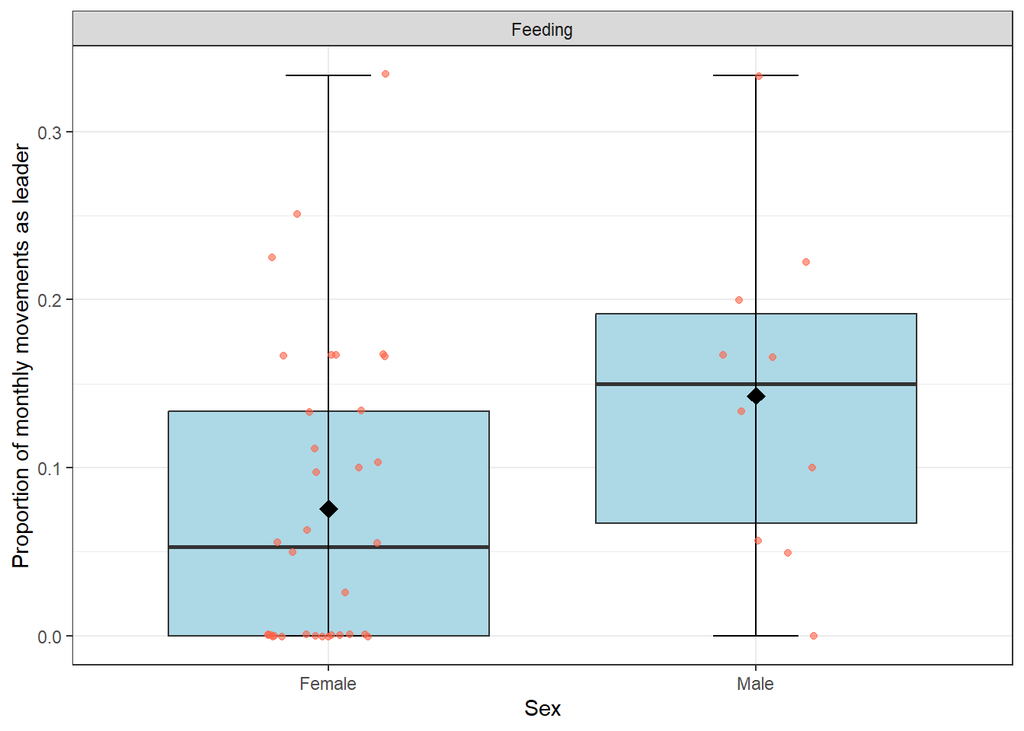

```r
# Filtramos solo el contexto Feeding
df_feeding <- subset(df, context == "Feeding")

my_comparisons <- list( c("F", "M"))

# Boxplot
ggplot(df_feeding, aes(x = sex, y = prop_leader, fill = sex)) +
  geom_boxplot(outlier.shape = NA) +   # caja
  stat_boxplot(geom = "errorbar", width = 0.2) +  # whiskers encima
  geom_jitter(width = 0.15, alpha = 0.6, color = "tomato") +
  # geom_boxplot(width = 0.6, alpha = 0.6) +
  # geom_jitter(width = 0.15, alpha = 0.4, color = "red", size = 2) +
  stat_summary(fun = mean, geom = "point", shape = 23, size = 3, fill = "black") +
  theme_bw() +
  facet_wrap(~context) +
  labs(x = "Sex", y = "Proportion of monthly movements as leader") +
  scale_x_discrete(name = "Sex", labels = c("F" = "Female", "M" = "Male")) +
  scale_fill_manual(values = c("F" = "lightblue", "M" = "lightblue"))+
  theme(legend.position = "none")
```

## 2nd model: order index progression

```r
model2 <- run_model_order_index(df, predictor="sex", context_name="Feeding")
```

```
##
## Running models for context: Feeding and predictor: sex
```

```r
print(model2$summary_model)
```

```
## Generalized linear mixed model fit by maximum likelihood (Laplace
##   Approximation) [glmerMod]
##  Family: binomial  ( logit )
## Formula: cbind(n_front, n_back) ~ sex + (1 | ID)
##    Data: dat
##
##       AIC       BIC    logLik -2*log(L)  df.resid
##     208.7     214.1    -101.4     202.7        41
##
## Scaled residuals:
##     Min      1Q  Median      3Q     Max
## -1.4626 -0.3884  0.1266  0.3881  1.0823
##
## Random effects:
##  Groups Name        Variance Std.Dev.
##  ID     (Intercept) 1.527    1.236
## Number of obs: 44, groups:  ID, 22
##
## Fixed effects:
##             Estimate Std. Error z value Pr(>|z|)
## (Intercept)   0.3993     0.3215   1.242    0.214
## sexM         -0.5288     0.6650  -0.795    0.426
##
## Correlation of Fixed Effects:
##      (Intr)
## sexM -0.484
```

```r
print(model2$lrt)
```

```
## Data: dat
## Models:
## null2: cbind(n_front, n_back) ~ (1 | ID)
## model2: cbind(n_front, n_back) ~ sex + (1 | ID)
##        npar    AIC    BIC  logLik -2*log(L)  Chisq Df Pr(>Chisq)
## null2     2 207.35 210.91 -101.67    203.35
## model2    3 208.73 214.08 -101.37    202.73 0.6149  1     0.4329
```

Conclusions:

- Sex does not significantly influence feeding position (front vs. back) in this context.
- Individual differences play a larger role than sex in explaining variation in feeding behavior.
- There is no evidence that adding sex as a predictor improves the explanatory power of the model.
- Any apparent difference between males and females is small and not statistically supported.

### Results table

```r
statistical_table(model_list = model2)
```

```
##     Predictor          β        SE        95% C.I.          Z         p
## 1 (Intercept)  0.3993256 0.3214711 [-0.231, 1.029]  1.2421820 0.2141694
## 2        sexM -0.5288489 0.6649950 [-1.832, 0.775] -0.7952674 0.4264580
```

### Barplot

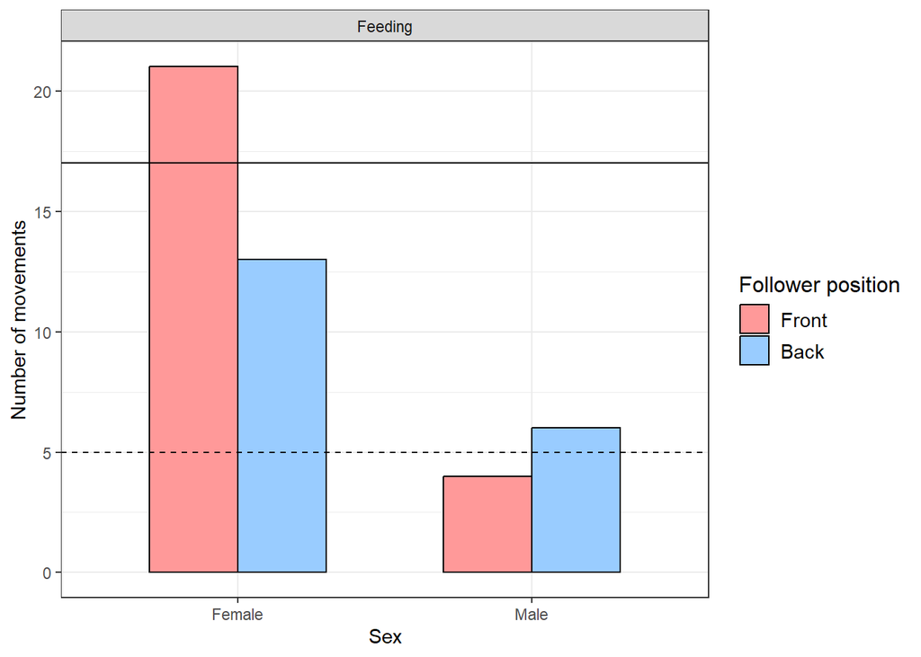

```r
# Crear un dataframe resumido por sexo y posición
df_bar <- df %>%
  filter(context == "Feeding") %>%  # filtrar solo Feeding
  group_by(sex, mean_poi_position,context) %>%
  summarise(n_movements = n(), .groups = "drop")

df_bar$mean_poi_position <- factor(
  df_bar$mean_poi_position,
  levels = c("Front", "Back")
)

# Barplot vertical
ggplot(df_bar, aes(x = sex, y = n_movements, fill = mean_poi_position)) +
  geom_bar(stat = "identity",
           position = "dodge",  # ancho entre barras
           width = 0.6,  # ancho de cada barra
           color = "black") +  # borde negro fino
  geom_hline(yintercept = 17, linetype = "solid") +  # Female
  geom_hline(yintercept = 5, linetype = "dashed") + # Male
  scale_fill_manual(values = c("Front" = "#FF9999", "Back" = "#99CCFF"),
                      # breaks = c("Front", "Back"),
                    name = "Follower position") +
  scale_y_continuous(name = "Number of movements") +
  scale_x_discrete(name = "Sex", labels = c("F" = "Female", "M" = "Male")) +
  theme_bw() +
  facet_wrap(~context) +
  theme(
    legend.title = element_text(size = 12),
    legend.text = element_text(size = 11),
    plot.title = element_text(size = 16, face = "bold", hjust = 0.5)
  )
```

# 2nd prediction: predictor = reproductive status and context = Feeding

## 1st model: proportion of leadership

```r
model1 <- run_model_leader_prop(df, predictor="repro_status", context_name="Feeding")
```

```
##
## Running models for context: Feeding and predictor: repro_status
```

```r
print(model1$summary_model)
```

```
## Generalized linear mixed model fit by maximum likelihood (Laplace
##   Approximation) [glmerMod]
##  Family: binomial  ( logit )
## Formula: cbind(n_leader, n_follower) ~ repro_status + (1 | ID)
##    Data: dat
##
##       AIC       BIC    logLik -2*log(L)  df.resid
##      98.4     104.5     -45.2      90.4        30
##
## Scaled residuals:
##     Min      1Q  Median      3Q     Max
## -1.1737 -0.6681 -0.3980  0.2769  1.9666
##
## Random effects:
##  Groups Name        Variance Std.Dev.
##  ID     (Intercept) 0.2358   0.4856
## Number of obs: 34, groups:  ID, 17
##
## Fixed effects:
##                 Estimate Std. Error z value Pr(>|z|)
## (Intercept)      -3.5669     0.4589  -7.772 7.72e-15 ***
## repro_statusAFD   1.3598     0.6694   2.031  0.04221 *
## repro_statusAFL   1.5626     0.5145   3.037  0.00239 **
## ---
## Signif. codes:  0 '***' 0.001 '**' 0.01 '*' 0.05 '.' 0.1 ' ' 1
##
## Correlation of Fixed Effects:
##             (Intr) rp_AFD
## rpr_sttsAFD -0.636
## rpr_sttsAFL -0.861  0.568
```

```r
print(model1$posthoc)
```

```
##
##   General Linear Hypotheses
##
## Multiple Comparisons of Means: Tukey Contrasts
##
##
## Linear Hypotheses:
##                Estimate
## AFD - AFC == 0   1.3598
## AFL - AFC == 0   1.5626
## AFL - AFD == 0   0.2028
```

```r
print(model1$lrt)
```

```
## Data: dat
## Models:
## null1: cbind(n_leader, n_follower) ~ (1 | ID)
## model1: cbind(n_leader, n_follower) ~ repro_status + (1 | ID)
##        npar     AIC    BIC  logLik -2*log(L)  Chisq Df Pr(>Chisq)
## null1     2 103.424 106.48 -49.712    99.424
## model1    4  98.419 104.52 -45.209    90.419 9.0052  2    0.01108 *
## ---
## Signif. codes:  0 '***' 0.001 '**' 0.01 '*' 0.05 '.' 0.1 ' ' 1
```

Conclusions:

- Reproductive status had a significant effect on the probability of being a leader versus a follower during feeding.
- Individuals in the AFD reproductive status had a significantly higher likelihood of leading compared to AFC individuals.
- Individuals in the AFL reproductive status also had a significantly higher likelihood of leading compared to AFC individuals.
- There was no meaningful difference in leadership probability between AFL and AFD individuals.
- Model comparison confirmed that including reproductive status improved model fit relative to the null model.

### Results table

```r
statistical_table(model_list = model1)
```

```
##         Predictor         β        SE         95% C.I.         Z            p
## 1     (Intercept) -3.566880 0.4589361 [-4.466, -2.667] -7.772063 7.721826e-15
## 2 repro_statusAFD  1.359774 0.6693524   [0.048, 2.672]  2.031477 4.220668e-02
## 3 repro_statusAFL  1.562579 0.5144939   [0.554, 2.571]  3.037118 2.388523e-03
```

### Boxplot

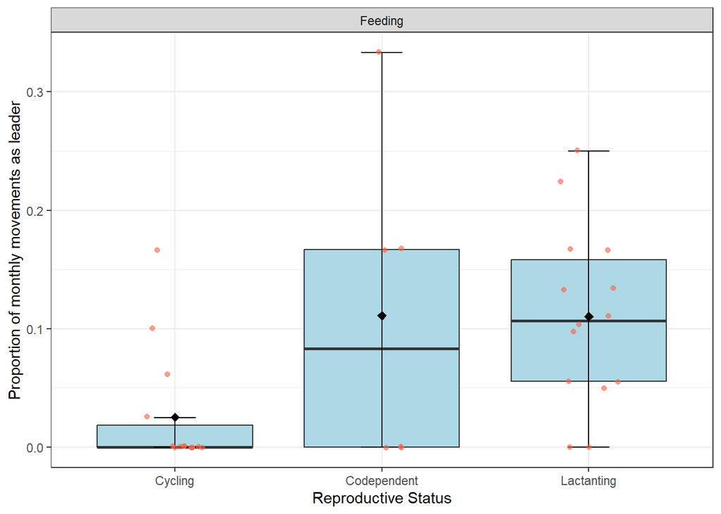

```r
# Filtramos solo el contexto Feeding
df_females <- subset(df, sex == "F") |>
  subset(context == "Feeding")


ggplot(df_females, aes(x = repro_status, y = prop_leader, fill = repro_status)) +
 geom_boxplot(outlier.shape = NA) +   # caja
  stat_boxplot(geom = "errorbar", width = 0.2) +  # whiskers encima
  geom_jitter(width = 0.15, alpha = 0.6, color = "tomato") +
  stat_summary(fun = mean, geom = "point", shape = 23, size = 2, fill = "black") +
  theme_bw() +
  facet_wrap(~context) +
  labs(x = "Reproductive status", y = "Proportion of monthly movements as leader") +
  scale_fill_manual(values = c("AFC" = "lightblue", "AFD" = "lightblue", "AFL" = "lightblue"))+
  scale_x_discrete(name = "Reproductive Status", labels = c("AFC" = "Cycling", "AFD" = "Codependent", "AFL" = "Lactanting")) +
  theme(legend.position = "none")
```

FIGURE 3: Differences among females in different reproductive states in leadership during group movements toward feeding trees in two groups of mantled howler monkeys studied at xxxxxxx (Ecuador), between July and October 2024. For illustrating purposes, leadership is represented as the proportion of monthly movements led by each individual. Thick lines inside the boxes are the medians; black diamonds are the means; box limits are the 25th and 75th percentiles; whiskers indicate 1.5*interquartile ranges. Data points are plotted as red circles. Reproductive status effect (GLMM, LRT p = 0.011); AFD > AFC (p = 0.042), AFL > AFC (p = 0.002). N = 34 movements from 17 subjects.

## 2nd model: order index progression

```r
model2 <- run_model_order_index(df, predictor="repro_status", context_name="Feeding")
```

```
##
## Running models for context: Feeding and predictor: repro_status
```

```r
print(model2$summary_model)
```

```
## Generalized linear mixed model fit by maximum likelihood (Laplace
##   Approximation) [glmerMod]
##  Family: binomial  ( logit )
## Formula: cbind(n_front, n_back) ~ repro_status + (1 | ID)
##    Data: dat
##
##       AIC       BIC    logLik -2*log(L)  df.resid
##     145.9     152.0     -68.9     137.9        30
##
## Scaled residuals:
##      Min       1Q   Median       3Q      Max
## -1.41046 -0.62231  0.08282  0.47571  0.93797
##
## Random effects:
##  Groups Name        Variance Std.Dev.
##  ID     (Intercept) 0.4947   0.7033
## Number of obs: 34, groups:  ID, 17
##
## Fixed effects:
##                 Estimate Std. Error z value Pr(>|z|)
## (Intercept)      -0.8038     0.3221  -2.496   0.0126 *
## repro_statusAFD   2.6972     0.6531   4.130 3.63e-05 ***
## repro_statusAFL   1.8782     0.4461   4.210 2.55e-05 ***
## ---
## Signif. codes:  0 '***' 0.001 '**' 0.01 '*' 0.05 '.' 0.1 ' ' 1
##
## Correlation of Fixed Effects:
##             (Intr) rp_AFD
## rpr_sttsAFD -0.501
## rpr_sttsAFL -0.729  0.367
```

```r
print(model2$posthoc)
```

```
##
##   General Linear Hypotheses
##
## Multiple Comparisons of Means: Tukey Contrasts
##
##
## Linear Hypotheses:
##                Estimate
## AFD - AFC == 0    2.697
## AFL - AFC == 0    1.878
## AFL - AFD == 0   -0.819
```

```r
print(model2$lrt)
```

```
## Data: dat
## Models:
## null2: cbind(n_front, n_back) ~ (1 | ID)
## model2: cbind(n_front, n_back) ~ repro_status + (1 | ID)
##        npar    AIC    BIC  logLik -2*log(L)  Chisq Df Pr(>Chisq)
## null2     2 158.82 161.87 -77.409    154.82
## model2    4 145.89 152.00 -68.945    137.89 16.927  2   0.000211 ***
## ---
## Signif. codes:  0 '***' 0.001 '**' 0.01 '*' 0.05 '.' 0.1 ' ' 1
```

Conclusions:

- Reproductive status has a strong and statistically significant effect on feeding response position.
- Both AFD and AFL show higher front responses than AFC, with AFD showing the strongest effect.
- Individual differences contribute meaningfully to variation in responses.

### Results table

```r
statistical_table(model_list = model2)
```

```
##         Predictor          β        SE         95% C.I.         Z            p
## 1     (Intercept) -0.8038407 0.3220990 [-1.435, -0.173] -2.495632 1.257329e-02
## 2 repro_statusAFD  2.6972062 0.6530839   [1.417, 3.977]  4.129954 3.628362e-05
## 3 repro_statusAFL  1.8781949 0.4460932   [1.004, 2.753]  4.210320 2.550094e-05
```

### Barplot

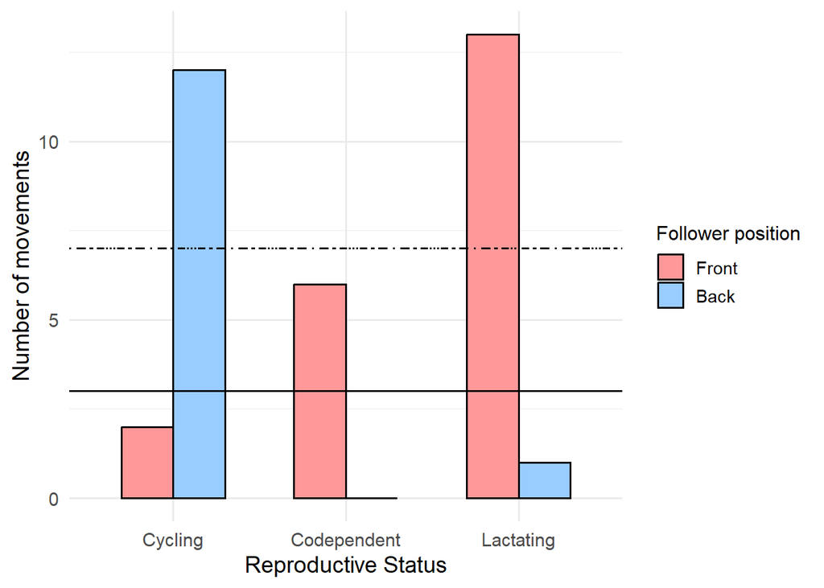

```r
#crear un dataframe resumido por repro status y posición
df_bar <- df_females %>%
  filter(context == "Feeding") %>%
  group_by(repro_status, mean_poi_position,context) %>%
  summarise(n_movements = n(), .groups = "drop")

df_bar <- rbind(df_bar,
                data.frame(repro_status = "AFD", mean_poi_position = "Back", context = "Feeding", n_movements = 0)
                )

df_bar$mean_poi_position <- factor(
  df_bar$mean_poi_position,
  levels = c("Front", "Back")
)

# Barplot vertical
ggplot(df_bar, aes(x = repro_status, y = n_movements, fill = mean_poi_position)) +
  geom_bar(stat = "identity",
           position = "dodge",  # ancho entre barras
           width = 0.6,  # ancho de cada barra
           color = "black") +  # borde negro fino
  geom_hline(yintercept = 7, linetype = "dotted") +  # Cycling
  geom_hline(yintercept = 3, linetype = "solid") + # Codependent
  geom_hline(yintercept = 7, linetype = "dotdash") + # Lactating
  scale_fill_manual(values = c("Front" = "#FF9999", "Back" = "#99CCFF"),
                    name = "Follower position") +
  scale_y_continuous(name = "Number of movements") +
  scale_x_discrete(name = "Reproductive Status", labels = c("AFC" = "Cycling", "AFD" = "Codependent", "AFL" = "Lactating")) +
  theme_minimal(base_size = 14) +
  theme(
    legend.title = element_text(size = 12),
    legend.text = element_text(size = 11),
    plot.title = element_text(size = 16, face = "bold", hjust = 0.5)
  )
```

FIGURE 4 Differences among females in different reproductive states in non‐leading positions occupied during group movements toward feeding trees in two groups of mantled howler monkeys studied at at xxxxxxx (Ecuador), between July and October 2024.For illustration purposes, the expected number of movements per position per reproductive status under a 50:50% situation is represented as lines (solid = Codependent, dotdash = Lactating, dotted = Cycling), corrected by the total number of sampled subjects of each reproductive status (Codependent = 3 subjects, Lactating = 7 and Cycling = 7). GLMM (binomial): effect of reproductive status (LRT, p = 0.00021); AFD vs AFC: p < 0.001, AFL vs AFC: p < 0.001; AFL vs AFD: n.s.. N = 34 movements.

# 3rd prediction: predictor = sex and context = Defense

## 1st model: proportion of leadership

```r
model1 <- run_model_leader_prop(df, predictor="sex", context_name="Defense")
```

```
##
## Running models for context: Defense and predictor: sex
```

```r
print(model1$summary_model)
```

```
## Generalized linear mixed model fit by maximum likelihood (Laplace
##   Approximation) [glmerMod]
##  Family: binomial  ( logit )
## Formula: cbind(n_leader, n_follower) ~ sex + (1 | ID)
##    Data: dat
##
##       AIC       BIC    logLik -2*log(L)  df.resid
##      96.4     101.8     -45.2      90.4        41
##
## Scaled residuals:
##     Min      1Q  Median      3Q     Max
## -1.5826 -0.6075 -0.3038  0.4440  2.7993
##
## Random effects:
##  Groups Name        Variance Std.Dev.
##  ID     (Intercept) 0.3835   0.6193
## Number of obs: 44, groups:  ID, 22
##
## Fixed effects:
##             Estimate Std. Error z value Pr(>|z|)
## (Intercept)  -3.3099     0.3648  -9.073  < 2e-16 ***
## sexM          2.1918     0.5085   4.310 1.63e-05 ***
## ---
## Signif. codes:  0 '***' 0.001 '**' 0.01 '*' 0.05 '.' 0.1 ' ' 1
##
## Correlation of Fixed Effects:
##      (Intr)
## sexM -0.695
```

```r
print(model1$lrt)
```

```
## Data: dat
## Models:
## null1: cbind(n_leader, n_follower) ~ (1 | ID)
## model1: cbind(n_leader, n_follower) ~ sex + (1 | ID)
##        npar     AIC    BIC  logLik -2*log(L)  Chisq Df Pr(>Chisq)
## null1     2 109.094 112.66 -52.547   105.094
## model1    3  96.436 101.79 -45.218    90.436 14.657  1  0.0001289 ***
## ---
## Signif. codes:  0 '***' 0.001 '**' 0.01 '*' 0.05 '.' 0.1 ' ' 1
```

Conclusions:

- Sex has a strong and statistically significant effect on defensive role.
- Males are substantially more likely to act as leaders during defense than females.
- Individual differences contribute meaningfully to variation in defensive behavior.

### Results table

```r
statistical_table(model_list = model1)
```

```
##     Predictor         β        SE         95% C.I.         Z            p
## 1 (Intercept) -3.309930 0.3648111 [-4.025, -2.595] -9.072997 1.157880e-19
## 2        sexM  2.191775 0.5085456   [1.195, 3.189]  4.309889 1.633364e-05
```

### Boxplot

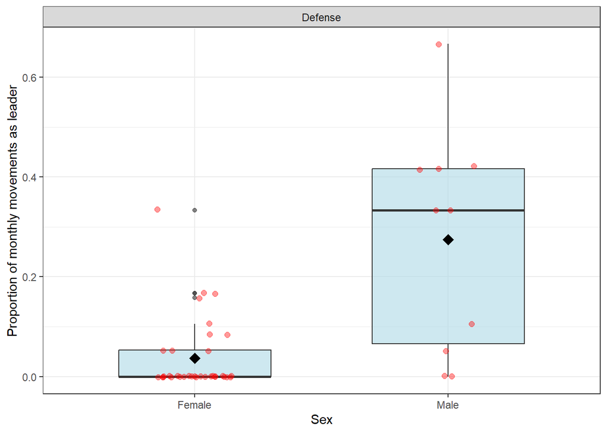

```r
# Filtramos solo el contexto Defense
df_defense <- subset(df, context == "Defense")

# Boxplot
ggplot(df_defense, aes(x = sex, y = prop_leader, fill = sex)) +
  geom_boxplot(width = 0.6, alpha = 0.6) +
  geom_jitter(width = 0.15, alpha = 0.4, color = "red", size = 2) +
  stat_summary(fun = mean, geom = "point", shape = 23, size = 3, fill = "black") +
  theme_bw() +
  facet_wrap(~context) +
  labs(x = "Sex", y = "Proportion of monthly movements as leader") +
  scale_x_discrete(name = "Sex", labels = c("F" = "Female", "M" = "Male")) +
  scale_fill_manual(values = c("F" = "lightblue", "M" = "lightblue"))+
  theme(legend.position = "none")
```

FIGURE 5: Differences between sexes in leadership during group movements in associantion with loud calls in two groups of mantled howler monkeys studied at xxxxxxx (Ecuador), between July and October 2024. For illustrating purposes, leadership is represented as the proportion of monthly movements led by each individual. Thick lines inside the boxes are the medians; black diamonds are the means; box limits are the 25th and 75th percentiles; whiskers indicate 1.5*interquartile ranges. Data points are plotted as red circles. Sex effect on leadership during defense (GLMM, LRT p = 0.00013), with higher leadership probability in males. N = 44 movements from 22 subjects.

## 2nd model: order index progression

```r
model2 <- run_model_order_index(df, predictor="sex", context_name="Defense")
```

```
##
## Running models for context: Defense and predictor: sex
```

```r
print(model2$summary_model)
```

```
## Generalized linear mixed model fit by maximum likelihood (Laplace
##   Approximation) [glmerMod]
##  Family: binomial  ( logit )
## Formula: cbind(n_front, n_back) ~ sex + (1 | ID)
##    Data: dat
##
##       AIC       BIC    logLik -2*log(L)  df.resid
##     171.7     177.1     -82.9     165.7        41
##
## Scaled residuals:
##      Min       1Q   Median       3Q      Max
## -1.72213 -0.54332  0.07365  0.56975  1.65470
##
## Random effects:
##  Groups Name        Variance Std.Dev.
##  ID     (Intercept) 0.5871   0.7662
## Number of obs: 44, groups:  ID, 22
##
## Fixed effects:
##             Estimate Std. Error z value Pr(>|z|)
## (Intercept)   0.1416     0.2237   0.633    0.527
## sexM          0.4726     0.4865   0.972    0.331
##
## Correlation of Fixed Effects:
##      (Intr)
## sexM -0.462
```

```r
print(model2$lrt)
```

```
## Data: dat
## Models:
## null2: cbind(n_front, n_back) ~ (1 | ID)
## model2: cbind(n_front, n_back) ~ sex + (1 | ID)
##        npar    AIC    BIC  logLik -2*log(L)  Chisq Df Pr(>Chisq)
## null2     2 170.69 174.26 -83.346    166.69
## model2    3 171.75 177.10 -82.875    165.75 0.9426  1     0.3316
```

Conclusions:

- Sex has no detectable effect on the direction (front vs back) of defensive responses.
- Variation in defensive response direction is driven primarily by individual differences, not sex.
- In contrast to leader–follower defense, front–back positioning during defense is sex-independent.

### Results table

```r
statistical_table(model_list = model2)
```

```
##     Predictor         β        SE        95% C.I.         Z         p
## 1 (Intercept) 0.1415973 0.2237332  [-0.297, 0.58] 0.6328845 0.5268091
## 2        sexM 0.4726430 0.4864580 [-0.481, 1.426] 0.9716008 0.3312492
```

### Barplot

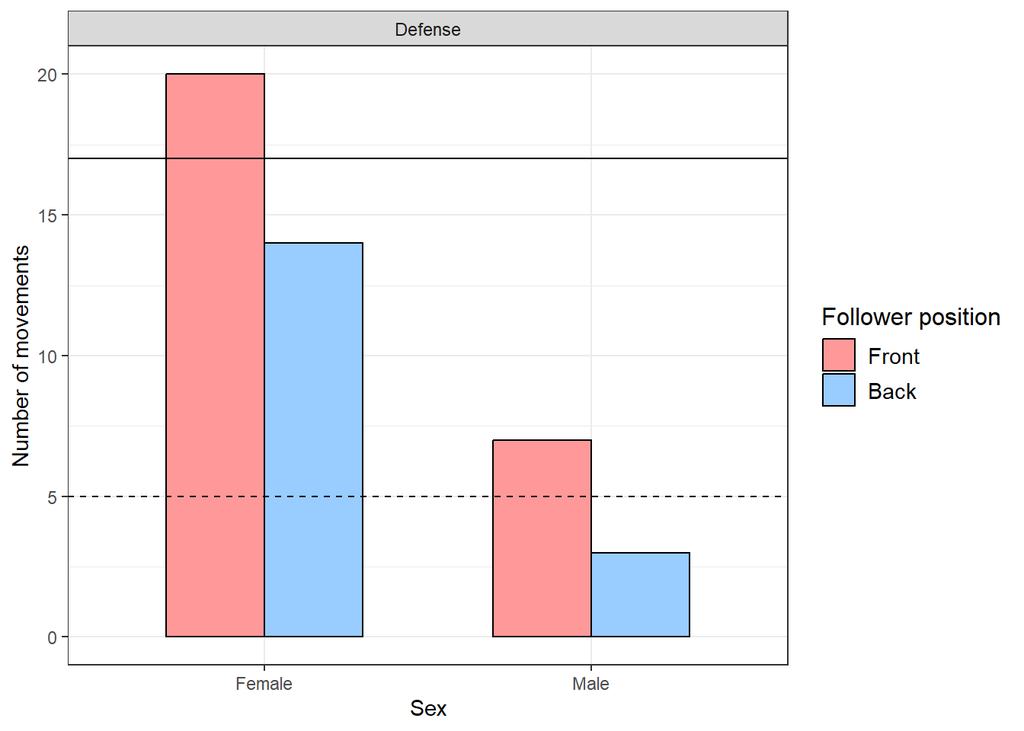

```r
# Crear un dataframe resumido por sexo y posición
df_bar <- df %>%
  filter(context == "Defense") %>%  # filtrar solo Feeding
  group_by(sex, mean_poi_position,context) %>%
  summarise(n_movements = n(), .groups = "drop")

df_bar$mean_poi_position <- factor(
  df_bar$mean_poi_position,
  levels = c("Front", "Back")
)

# Barplot vertical
ggplot(df_bar, aes(x = sex, y = n_movements, fill = mean_poi_position)) +
  geom_bar(stat = "identity",
           position = "dodge",  # ancho entre barras
           width = 0.6,  # ancho de cada barra
           color = "black") +  # borde negro fino
  geom_hline(yintercept = 17, linetype = "solid") +  # Female
  geom_hline(yintercept = 5, linetype = "dashed") + # Male
  scale_fill_manual(values = c("Front" = "#FF9999", "Back" = "#99CCFF"),
                    name = "Follower position") +
  scale_y_continuous(name = "Number of movements") +
  scale_x_discrete(name = "Sex", labels = c("F" = "Female", "M" = "Male")) +
  theme_bw() +
  facet_wrap(~context) +
  theme(
    legend.title = element_text(size = 12),
    legend.text = element_text(size = 11),
    plot.title = element_text(size = 16, face = "bold", hjust = 0.5)
  )
```

FIGURE 6 Differences between sexes in non‐leading positions occupied during group movements in associantion with loud calls in two groups of mantled howler monkeys studied at at xxxxxxx (Ecuador), between July and October 2024.For illustration purposes, the expected number of movements per position per sex under a 50:50% situation is represented as lines (solid = females, dashed = males), corrected by the total number of sampled subjects of each sex (females = 17 subjects, males = 5). No significant sex effect (GLMM, LRT p = 0.332). N = 44 movements.